# A random walk simulation and the Arcsine distribution

### Introduction

Our goal in the next lines is to simulate some of the most simple but also important stochastic processes. We focus on simulating a simple random walk.

A random walk is a random process that describes a path that consists of a succession of random steps on some mathematical space.

### The Simple Random Walk

More formally, we can define:

Let $\{X_i\}_{i \ge 1}$ be a succession of identically distributed independent random variables with $P(X_i = 1) = p$ and $P(X_i = -1) = 1-p$. Then, the process $\{S_n\}_{n \ge 0}$ defined by:
$$S_n = S_0 + \sum_{i=1}^{n} X_i,$$
where $S_0$ is a constant, is called a **simple random walk** with parameter $p \in (0,1)$.

Notice that here the word *‘simple’* means that the location can only jump to neighboring sites. In general, this is not the case.

We say that the random walk is **symmetric** if $p = 1/2$.

### The Simulation

To be able to simulate this process we must first know how to simulate $X_i$ values. We can do this from the [Bernoulli random variables](https://en.wikipedia.org/wiki/Bernoulli_distribution) simulations.

The following function generates a trajectory of length $n$ of the process $S$. The values by default are $p = 1/2$, $n = 100$ and $S_0 = 0$. Notice that it returns a *dataframe* object with the first column $\{i\}_{i=0,\dots,n}$ and the second one $\{S_i\}_{i=0,\dots,n}$:

```r
SRW <- function(p = 0.5, n = 100, S0 = 0){
    X <- rbinom(n, 1, p)
    X <- X - 1 * (X == 0)
    S <- cumsum(c(S0, X))
    return(data.frame(n = 0:n, S = S))
}
```

An example of the *dataframe* that our function returns with $p = 1/2$, $n = 15$ and $S_0 = 10$:

```r
SRW(n = 15, S0 = 10)
```

| n | S |
| --- | --- |
| 0 | 10 |
| 1 | 11 |
| 2 | 10 |
| 3 | 9 |
| 4 | 8 |
| 5 | 9 |
| 6 | 10 |
| 7 | 9 |
| 8 | 8 |
| 9 | 9 |

[output cut: 6 more lines]

### A plot of a Simple Random Walk

The following instruction draws a trajectory of a random walk with $p = 1/2$, $n = 200$ and $S_0 = 0$:

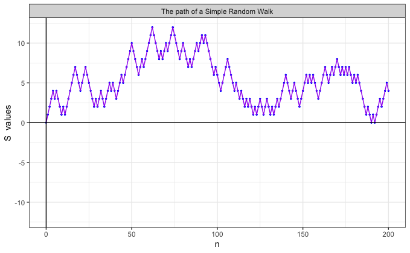

```r
library(ggplot2)

df <- SRW(n = 200)

bound <- max(abs(max(df[2])), abs(min(df[2]))) # In order to center the drawing

g <- ggplot(df, aes(n, S)) +
    geom_point(size = 0.5, colour = 'blue') +
    labs(x = "n", y = "S  values") +
    ylim(-bound, bound) +
    geom_line(colour = 'purple') +
    geom_hline(yintercept = 0) +
    geom_vline(xintercept = 0) +
    facet_grid(~"The path of a Simple Random Walk") +
    theme_bw()

print(g)
```

### A couple of variables: $\tau$ and $\gamma$

We suppose now that $S$ is a simple random walk with $S_0 = 0$ and that we simulate $S$ from $0$ to $n$. Then we define the variables:
$$\tau := {\arg \max}_{0 \le k \le n}S_k,$$
$$\gamma := \max_{0 \le k \le n}\{S_k =
0\}.$$

That is to say, the instant of time when $S$ reaches its maximum and the last instant of time where it is zero, respectively.

Notice that we have defined $\gamma$ supposing $S_0 = 0$. We could also define it in a more general sense as $\gamma := \max_{0 \le k \le n}\{S_k = S_0\}$, but in fact is the same, just applying a translation to all the values of $S$.

Let’s gonna calculate the values of $\tau$ and $\gamma$ for the random walk we have just plotted.

```r
tau <- function(data_frame){
    tau_vect <- which(data_frame['S'] == max(data_frame['S']))
    tau <- tail(tau_vect, n = 1) - 1
    return(tau)
}
tau(df)
```

```
[1] 74
```

```r
gamma <- function(data_frame){
    gamma_vect <- which(data_frame['S'] == data_frame[1,2])
    gamma <- tail(gamma_vect, n = 1) - 1
    return(gamma)
}
gamma(df)
```

```
[1] 192
```

In the chart below we can see these values, $\tau$ in **black** and $\gamma$ in **red**:

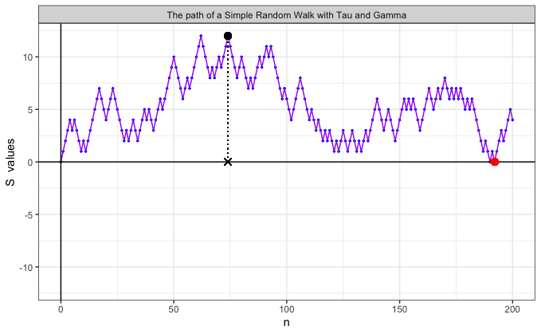

```r
g_tau_gamma <- g +
    geom_point(aes(x = tau(df), y = df[tau(df) + 1, 2]), colour="black", size = 2.7) +
    geom_point(aes(x = tau(df), y = 0), colour="black", size = 2.7, shape = 4) +
    geom_segment(aes(x = tau(df), y = 0, xend = tau(df), yend = df[tau(df) + 1, 2]),
                 linetype = "dotted", size = 0.2) +
    geom_point(aes(x = gamma(df), y = df[gamma(df) + 1, 2]), colour="red", size = 2.7) +
    facet_grid(~"The path of a Simple Random Walk with Tau and Gamma")

print(g_tau_gamma)
```

### Using $\tau$ and $\gamma$

Now, let’s gonna do some interpretations about these variables. We write a code to generate 10000 observations of each of these variables. Afterwards, we gonna normalize these values considering $\tau / n$ and $\gamma / n$. Finally, we gonna make a couple of histograms of the normalized variables.

In order to do this, we gonna construct a new dataframe:

```r
m <- 10000
n <- 222
df_tau_gamma <- data.frame(tau = 1:m, gamma = 1:m, tau_norm = 0, gamma_norm = 0)

for(i in 1:m){
    df_aux <- SRW(n = n, S0 = 0)

    df_tau_gamma[i,1] <- tau(df_aux)
    df_tau_gamma[i,2] <- gamma(df_aux)
    df_tau_gamma[i,3] <- df_tau_gamma[i,1]/n
    df_tau_gamma[i,4] <- df_tau_gamma[i,2]/n
}
head(df_tau_gamma)
```

|  | tau | gamma | tau_norm | gamma_norm |
| --- | --- | --- | --- | --- |
| 1 | 167 | 220 | 0.752252252 | 0.99099099 |
| 2 | 215 | 86 | 0.968468468 | 0.38738739 |
| 3 | 2 | 114 | 0.009009009 | 0.51351351 |
| 4 | 205 | 90 | 0.923423423 | 0.40540541 |
| 5 | 215 | 16 | 0.968468468 | 0.07207207 |
| 6 | 170 | 48 | 0.765765766 | 0.21621622 |

Let’s plot now the two histograms:

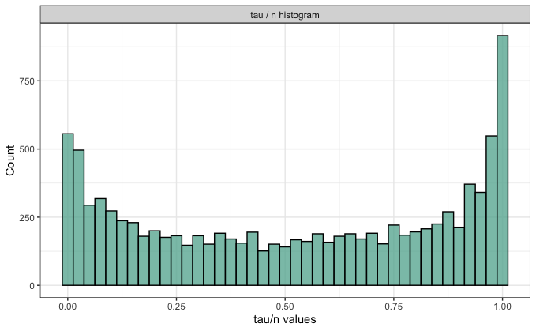

```r
hist_tau <- ggplot(df_tau_gamma, aes(x = tau_norm)) +
    geom_histogram(binwidth = 0.025, fill="#69b3a2", color="black", alpha=0.8) +
    labs(x = "tau/n values", y = "Count") +
    facet_grid(~"tau / n histogram") +
    theme_bw()

print(hist_tau)
```

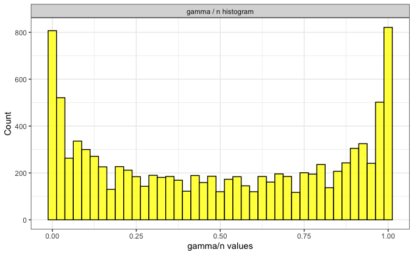

```r
hist_gamma <- ggplot(df_tau_gamma, aes(x = gamma_norm)) +
    geom_histogram(binwidth = 0.025, fill="yellow", color="black", alpha=0.8) +
    labs(x = "gamma/n values", y = "Count") +
    facet_grid(~"gamma / n histogram") +
    theme_bw()

print(hist_gamma)
```

### The Arcsine distribution

At this point, the shape of these two histograms may be familiar to one. Indeed, they are really similar to the density function of an arcsine distribution:

The **arcsine distribution** is the probability distribution whose probability density function is:
$$f(x) = \frac{1}{\pi
\sqrt{x(1-x)}}\cdot\mathbb{1}_{(0,1)}(x)$$
Finally, we gonna a paint this function over each one of the histograms:

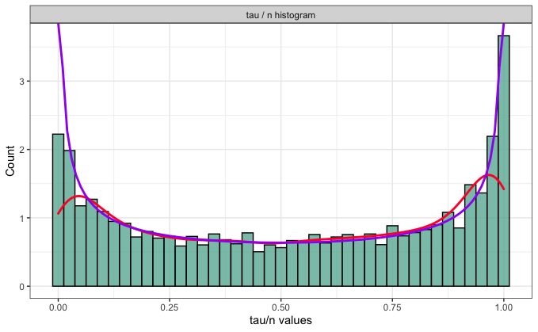

```r
library(VaRES)

hist_tau_arcsine <- ggplot(df_tau_gamma, aes(x = tau_norm)) +
    geom_histogram(aes(y =..density..),
                   binwidth = 0.025, fill="#69b3a2", color="black", alpha=0.8) +
    labs(x = "tau/n values", y = "Count") +
    facet_grid(~"tau / n histogram") +
    theme_bw() +
    geom_density(colour = "#FF0033", size = 1) +
    stat_function(aes(x = tau_norm), fun = darcsine, geom="line", colour = "purple", size = 1)

print(hist_tau_arcsine)
```

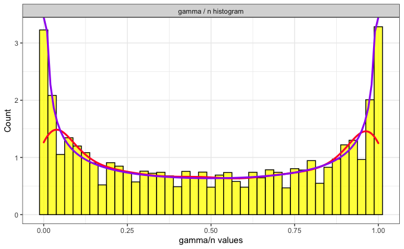

```r
hist_gamma_arcsine <- ggplot(df_tau_gamma, aes(x = gamma_norm)) +
    geom_histogram(aes(y =..density..),
                   binwidth = 0.025, fill="yellow", color="black", alpha=0.8) +
    labs(x = "gamma/n values", y = "Count") +
    facet_grid(~"gamma / n histogram") +
    theme_bw() +
    geom_density(colour = "#FF0033", size = 1.1) +
    stat_function(aes(x = gamma_norm), fun = darcsine, geom="line",
                  colour = "purple", size = 1.1)

print(hist_gamma_arcsine)
```

… to be continued.